# QSA(P)R for Ecotoxicology:

Daphnia magna

P J Kowalczyk

2020-09-17 09:00:30

# Introduction

**Daphnia magna** is a small planktonic crustacean (adult length 1.5–5.0 mm) that belongs to the subclass Phyllopoda. It inhabits a variety of freshwater environments, ranging from acidic swamps to rivers made of snow runoff, and is broadly distributed throughout the Northern Hemisphere and South Africa.

In the recent years, ecotoxicological hazard potential of biocidal products has been receiving increasing attention in the industries and regulatory agencies. Biocides/pesticides are currently one of the most studied groups of compounds, and their registration cannot be done without the empirical toxicity information. In view of limited experimental data available for these compounds, we have developed Quantitative Structure-Activity Relationship (QSAR) models for the toxicity of biocides to Daphnia magna following principles of QSAR modeling recommended by the OECD (Organization for Economic Cooperation and Development).

# Data Retrieval

Data was retrieved from K.Khan, *et al.*, **QSAR Modeling of Daphnia Magna and Fish Toxicities of Biocides Using 2D Descriptors** Chemosphere, **229** (2019) 8 - 17.

Experimental results were reported for 132 molecules (observations).

| CAS | SMILES | pEC50 |
| --- | --- | --- |
| 112-53-8 | OCCCCCCCCCCCC | 2.7652493 |
| 94-75-7 | O=C(O)COc1ccc(cc1Cl)Cl | 3.2167184 |
| 57960-19-7 | O=C(OC=1C(=O)c2ccccc2(C(=O)C=1CCCCCCCCCCCC))C | 7.9938995 |
| 101007-06-1 | N#CC(OC(=O)C1C(C=CC(=O)OC(C(F)(F)F)C(F)(F)F)C1(C)(C))c3cccc(Oc2ccccc2)c3 | 10.3911597 |
| 348635-87-0 | O=S(=O)(c1ncn(n1)S(=O)(=O)N(C)C)n3c2cc(F)ccc2c(c3C)Br | 7.1005103 |
| 120162-55-2 | O=C(Nc1nc(OC)cc(n1)OC)NS(=O)(=O)c2c(cnn2C)c3nnn(n3)C | 3.0503450 |
| 82560-54-1 | O=C(Oc2cccc1c2(OC(C)(C)C1))N(C)SN(CCC(=O)OCC)C(C)C | 7.6134084 |
| 56634-95-8 | N#Cc1cc(c(OC(=O)CCCCCC)c(c1)Br)Br | 7.0986995 |
| 1689-99-2 | N#Cc1cc(c(OC(=O)CCCCCCC)c(c1)Br)Br | 6.9619924 |
| 95465-99-9 | O=P(OCC)(SC(C)CC)SC(C)CC | 8.5570097 |
| 1563-66-2 | O=C(Oc2cccc1c2(OC(C)(C)C1))NC | 7.3718143 |
| 55285-14-8 | O=C(Oc2cccc1c2(OC(C)(C)C1))N(C)SN(CCCC)CCCC | 8.4043889 |
| 500008-45-7 | O=C(Nc1c(cc(cc1C)Cl)C(=O)NC)c3cc(nn3(c2ncccc2Cl))Br | 7.6196420 |
| 1698-60-8 | O=C1C(=C(N)C=NN1c2ccccc2)Cl | 3.2251134 |
| 1897-45-6 | N#Cc1c(c(C#N)c(c(c1Cl)Cl)Cl)Cl | 6.6923246 |
| 2921-88-2 | n1c(OP(OCC)(OCC)=S)c(cc(c1Cl)Cl)Cl | 9.5448119 |
| 5598-13-0 | n1c(OP(OC)(OC)=S)c(cc(c1Cl)Cl)Cl | 8.7304323 |
| 143807-66-3 | O=C(NN(C(=O)c1cc(cc(c1)C)C)C(C)(C)C)c3ccc2OCCCc2c3C | 2.8828746 |
| 1031756-98-5 | O=C(Nc1c(cc(cc1Br)Cl)C(=O)NC(C)C2CC2)c4cc(nn4(c3ncccc3Cl))Br | 6.8712052 |
| 39515-40-7 | N#CC(OC(=O)C1C(C=C(C)C)C1(C)(C))c3cccc(Oc2ccccc2)c3 | 8.9408973 |
| 333-41-5 | n1c(OP(OCC)(OCC)=S)cc(nc1C(C)C)C | 8.4834304 |
| 104653-34-1 | O=C2c1ccccc1SC(O)=C2C6c3ccccc3CC(c4ccc(cc4)c5ccc(cc5)Br)C6 | 8.0885468 |
| 149961-52-4 | O=C(NC)C(=NOC)c1ccccc1COc2cc(ccc2C)C | 6.9182938 |
| 131-72-6 | O=C(Oc1c(cc(cc1C(C)CCCCCC)N+[O-])N+[O-])C=CC | 7.9383767 |
| 66230-04-4 | N#CC(OC(=O)C(c1ccc(cc1)Cl)C(C)C)c3cccc(Oc2ccccc2)c3 | 9.1918131 |
| 64-17-5 | OCC | 0.6582206 |
| 126801-58-9 | O=C(Nc1nc(OC)cc(n1)OC)NS(=O)(=O)Oc2ccccc2(OCC) | 3.1132246 |
| 107-06-2 | C(CCl)Cl | 2.5975197 |
| 80844-07-1 | O(c1ccccc1)c2cccc(c2)COCC(c3ccc(OCC)cc3)(C)C | 8.6904516 |
| 153233-91-1 | Fc1cccc(F)c1C3=NC(c2ccc(cc2(OCC))C(C)(C)C)CO3 | 7.7043801 |

[output cut: 102 more lines]

The **pEC50** is defined as the negative logarithm of the EC50. If the EC50 equals 1 micromolar (10-6 molar), the log(EC50) is -6 and the pEC50 is 6. The advantage to expressing potency this way is that drugs with larger pEC50 values are more potent.

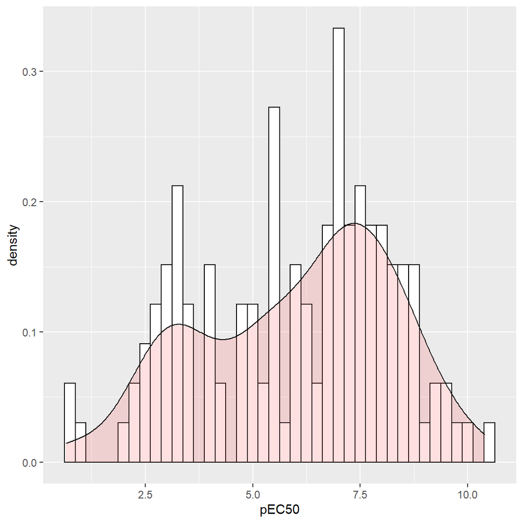

# Calculate Predictors

RDKit was used to calculate 200 predictors (variables) for each of the 132 molecules. The **SMILES** strings were used to encode the molecules.

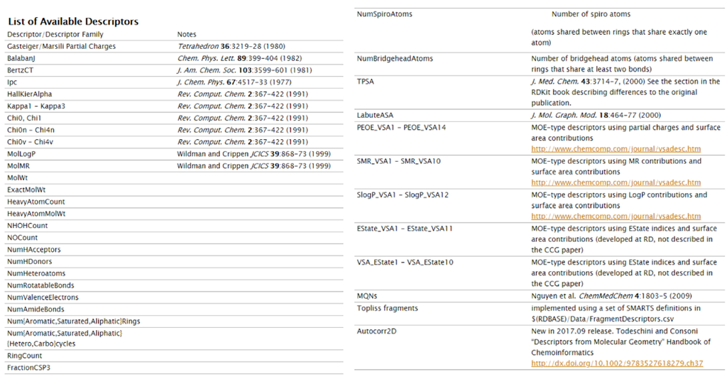

| CAS | SMILES | pEC50 | MaxEStateIndex | MinEStateIndex | MaxAbsEStateIndex | MinAbsEStateIndex | qed | MolWt | HeavyAtomMolWt | ExactMolWt | NumValenceElectrons | NumRadicalElectrons | MaxPartialCharge | MinPartialCharge | MaxAbsPartialCharge | MinAbsPartialCharge | FpDensityMorgan1 | FpDensityMorgan2 | FpDensityMorgan3 | BalabanJ | BertzCT | Chi0 | Chi0n | Chi0v | Chi1 | Chi1n | Chi1v | Chi2n | Chi2v | … |
| --- | --- | --- | --- | --- | --- | --- | --- | --- | --- | --- | --- | --- | --- | --- | --- | --- | --- | --- | --- | --- | --- | --- | --- | --- | --- | --- | --- | --- | --- | --- |
| 112-53-8 | OCCCCCCCCCCCC | 2.7652493 | 8.566064 | 0.3715278 | 8.566064 | 0.3715278 | 0.5129822 | 186.339 | 160.131 | 186.19837 | 80 | 0 | 0.0430524 | -0.3963766 | 0.3963766 | 0.0430524 | 0.6153846 | 1.0000000 | 1.3846154 | 2.7581498 | 71.193662 | 9.778175 | 9.225388 | 9.225388 | 6.414214 | 6.0233345 | 6.0233345 | 3.9055873 | 3.9055873 | … |
| 94-75-7 | O=C(O)COc1ccc(cc1Cl)Cl | 3.2167184 | 10.156713 | -1.0499846 | 10.156713 | 0.2997685 | 0.8519927 | 221.039 | 214.991 | 219.96940 | 70 | 0 | 0.3412236 | -0.4803484 | 0.4803484 | 0.3412236 | 1.4615385 | 2.1538462 | 2.6923077 | 2.7194415 | 325.165220 | 9.844935 | 6.458797 | 7.970655 | 6.092224 | 3.3900820 | 4.1460109 | 2.2571575 | 3.1007934 | … |
| 57960-19-7 | O=C(OC=1C(=O)c2ccccc2(C(=O)C=1CCCCCCCCCCCC))C | 7.9938995 | 12.844185 | -0.5730517 | 12.844185 | 0.0767369 | 0.3181397 | 384.516 | 352.260 | 384.23006 | 152 | 0 | 0.3076723 | -0.4220563 | 0.4220563 | 0.3076723 | 0.7857143 | 1.2857143 | 1.8214286 | 1.8777432 | 729.875626 | 20.355160 | 17.220569 | 17.220569 | 13.557749 | 10.6586312 | 10.6586312 | 7.5371338 | 7.5371338 | … |
| 101007-06-1 | N#CC(OC(=O)C1C(C=CC(=O)OC(C(F)(F)F)C(F)(F)F)C1(C)(C))c3cccc(Oc2ccccc2)c3 | 10.3911597 | 12.783148 | -5.8445545 | 12.783148 | 0.3136577 | 0.2169529 | 541.444 | 520.276 | 541.13239 | 202 | 0 | 0.4341563 | -0.4573708 | 0.4573708 | 0.4341563 | 0.9473684 | 1.5526316 | 2.1315789 | 1.6537221 | 1219.170312 | 28.302754 | 19.916496 | 19.916496 | 17.640232 | 11.0951015 | 11.0951015 | 9.0177205 | 9.0177205 | … |
| 348635-87-0 | O=S(=O)(c1ncn(n1)S(=O)(=O)N(C)C)n3c2cc(F)ccc2c(c3C)Br | 7.1005103 | 13.653785 | -4.3633381 | 13.653785 | 0.0844368 | 0.5745727 | 466.314 | 453.210 | 464.95764 | 140 | 0 | 0.3234382 | -0.2343198 | 0.3234382 | 0.2343198 | 1.1923077 | 1.8461538 | 2.4615385 | 2.2559079 | 1230.938350 | 19.438793 | 13.750888 | 16.969877 | 11.974105 | 7.0397639 | 10.6697889 | 5.5201754 | 9.9936846 | … |
| 120162-55-2 | O=C(Nc1nc(OC)cc(n1)OC)NS(=O)(=O)c2c(cnn2C)c3nnn(n3)C | 3.0503450 | 12.756175 | -4.3645337 | 12.756175 | 0.0298598 | 0.4912978 | 424.403 | 408.275 | 424.10258 | 154 | 0 | 0.3350669 | -0.4807654 | 0.4807654 | 0.3350669 | 1.1379310 | 1.7931034 | 2.3448276 | 1.8532770 | 1132.449261 | 21.181434 | 15.681899 | 16.498396 | 13.728714 | 7.8043497 | 9.2875130 | 5.4253940 | 7.0230901 | … |
| 82560-54-1 | O=C(Oc2cccc1c2(OC(C)(C)C1))N(C)SN(CCC(=O)OCC)C(C)C | 7.6134084 | 12.581380 | -0.5060270 | 12.581380 | 0.1247977 | 0.4728097 | 410.536 | 380.296 | 410.18754 | 156 | 0 | 0.4257020 | -0.4833023 | 0.4833023 | 0.4257020 | 1.3214286 | 2.0357143 | 2.6785714 | 1.9697921 | 707.836503 | 20.896977 | 17.481745 | 18.298242 | 13.125029 | 9.4944240 | 10.2247207 | 7.5194744 | 8.6995137 | … |
| 56634-95-8 | N#Cc1cc(c(OC(=O)CCCCCC)c(c1)Br)Br | 7.0986995 | 11.705622 | -0.2479530 | 11.705622 | 0.2479530 | 0.3927805 | 389.087 | 373.967 | 386.94695 | 102 | 0 | 0.3107554 | -0.4240947 | 0.4240947 | 0.3107554 | 1.2631579 | 1.8947368 | 2.4210526 | 2.6213538 | 471.704711 | 14.250712 | 10.709874 | 13.881867 | 9.078917 | 6.1793044 | 7.7653010 | 4.1655505 | 5.8742243 | … |
| 1689-99-2 | N#Cc1cc(c(OC(=O)CCCCCCC)c(c1)Br)Br | 6.9619924 | 11.775163 | -0.2429573 | 11.775163 | 0.2429573 | 0.3505533 | 403.114 | 385.978 | 400.96260 | 108 | 0 | 0.3107554 | -0.4240947 | 0.4240947 | 0.3107554 | 1.2000000 | 1.8000000 | 2.3500000 | 2.5216011 | 486.080357 | 14.957819 | 11.416980 | 14.588973 | 9.578917 | 6.6793044 | 8.2653010 | 4.5191038 | 6.2277776 | … |
| 95465-99-9 | O=P(OCC)(SC(C)CC)SC(C)CC | 8.5570097 | 12.455509 | -2.5313194 | 12.455509 | 0.4017958 | 0.5665946 | 270.400 | 247.216 | 270.08771 | 92 | 0 | 0.3131934 | -0.3138697 | 0.3138697 | 0.3131934 | 1.0666667 | 1.4666667 | 1.7333333 | 4.3716652 | 195.599069 | 11.897341 | 10.356228 | 12.883648 | 6.969674 | 5.5828939 | 10.1771866 | 3.5135377 | 11.5398963 | … |
| 1563-66-2 | O=C(Oc2cccc1c2(OC(C)(C)C1))NC | 7.3718143 | 11.153531 | -0.4845314 | 11.153531 | 0.2316592 | 0.7897379 | 221.256 | 206.136 | 221.10519 | 86 | 0 | 0.4119717 | -0.4833023 | 0.4833023 | 0.4119717 | 1.5000000 | 2.2500000 | 2.9375000 | 2.2980828 | 426.272091 | 11.759149 | 9.663903 | 9.663903 | 7.515968 | 5.2217444 | 5.2217444 | 4.4224477 | 4.4224477 | … |
| 55285-14-8 | O=C(Oc2cccc1c2(OC(C)(C)C1))N(C)SN(CCCC)CCCC | 8.4043889 | 12.557380 | -0.3799046 | 12.557380 | 0.2613092 | 0.5441258 | 380.554 | 348.298 | 380.21336 | 146 | 0 | 0.4257019 | -0.4833023 | 0.4833023 | 0.4257019 | 1.2307692 | 1.8846154 | 2.5000000 | 1.9767801 | 598.719132 | 19.156490 | 16.709219 | 17.525715 | 12.358504 | 9.5543823 | 10.2846790 | 7.3661415 | 8.5935612 | … |
| 500008-45-7 | O=C(Nc1c(cc(cc1C)Cl)C(=O)NC)c3cc(nn3(c2ncccc2Cl))Br | 7.6196420 | 13.004830 | -0.4902822 | 13.004830 | 0.1848904 | 0.5810426 | 483.153 | 469.041 | 480.97079 | 144 | 0 | 0.2740379 | -0.3550440 | 0.3550440 | 0.2740379 | 1.1785714 | 1.9285714 | 2.6071429 | 2.0468235 | 1083.833073 | 20.421921 | 14.756132 | 17.853987 | 13.311770 | 8.0152137 | 9.5641409 | 5.7514328 | 7.4075461 | … |
| 1698-60-8 | O=C1C(=C(N)C=NN1c2ccccc2)Cl | 3.2251134 | 11.678522 | -0.4140123 | 11.678522 | 0.0056916 | 0.7933823 | 221.647 | 213.583 | 221.03559 | 76 | 0 | 0.2918754 | -0.3960485 | 0.3960485 | 0.2918754 | 1.2666667 | 1.9333333 | 2.6000000 | 2.6602820 | 536.108919 | 10.836499 | 7.722092 | 8.478021 | 7.198377 | 4.2865527 | 4.6645172 | 2.9663987 | 3.3443631 | … |
| 1897-45-6 | N#Cc1c(c(C#N)c(c(c1Cl)Cl)Cl)Cl | 6.6923246 | 8.704536 | -0.0746296 | 8.704536 | 0.0362654 | 0.5249704 | 265.914 | 265.914 | 263.88156 | 70 | 0 | 0.1023787 | -0.1923229 | 0.1923229 | 0.1023787 | 0.6428571 | 1.0000000 | 1.2857143 | 3.7817196 | 440.580476 | 10.878315 | 6.406285 | 9.430001 | 6.540111 | 3.2031425 | 4.7150004 | 2.2295357 | 3.7413936 | … |
| 2921-88-2 | n1c(OP(OCC)(OCC)=S)c(cc(c1Cl)Cl)Cl | 9.5448119 | 5.937656 | -2.9184788 | 5.937656 | 0.0521296 | 0.5483413 | 350.591 | 339.503 | 348.92628 | 102 | 0 | 0.3813559 | -0.4039620 | 0.4039620 | 0.3813559 | 1.1666667 | 1.7222222 | 2.2222222 | 3.0061252 | 464.616237 | 13.759149 | 9.652878 | 13.631588 | 8.414833 | 5.0174953 | 8.7074273 | 2.9220286 | 7.0294819 | … |
| 5598-13-0 | n1c(OP(OC)(OC)=S)c(cc(c1Cl)Cl)Cl | 8.7304323 | 5.851276 | -2.8802844 | 5.851276 | 0.0306481 | 0.6201561 | 322.537 | 315.481 | 320.89498 | 90 | 0 | 0.3808309 | -0.4039743 | 0.4039743 | 0.3808309 | 1.1875000 | 1.7500000 | 2.2500000 | 3.0637669 | 437.130382 | 12.344935 | 8.238664 | 12.217375 | 7.414833 | 3.8424280 | 7.5323601 | 2.4516278 | 6.7729800 | … |
| 143807-66-3 | O=C(NN(C(=O)c1cc(cc(c1)C)C)C(C)(C)C)c3ccc2OCCCc2c3C | 2.8828746 | 13.271588 | -0.5876806 | 13.271588 | 0.2253737 | 0.7619567 | 394.515 | 364.275 | 394.22564 | 154 | 0 | 0.2723008 | -0.4932878 | 0.4932878 | 0.2723008 | 1.0344828 | 1.6896552 | 2.3103448 | 1.9144735 | 937.078625 | 21.344570 | 18.180030 | 18.180030 | 13.574406 | 10.0681558 | 10.0681558 | 8.7955268 | 8.7955268 | … |
| 1031756-98-5 | O=C(Nc1c(cc(cc1Br)Cl)C(=O)NC(C)C2CC2)c4cc(nn4(c3ncccc3Cl))Br | 6.8712052 | 13.236100 | -0.5025615 | 13.236100 | 0.0347156 | 0.3693254 | 602.114 | 584.978 | 598.91260 | 166 | 0 | 0.2740603 | -0.3492402 | 0.3492402 | 0.2740603 | 1.1875000 | 1.9375000 | 2.6250000 | 1.6719305 | 1212.895841 | 22.990835 | 16.703011 | 21.386862 | 15.240091 | 9.7200512 | 12.0619767 | 7.4368004 | 9.9472506 | … |
| 39515-40-7 | N#CC(OC(=O)C1C(C=C(C)C)C1(C)(C))c3cccc(Oc2ccccc2)c3 | 8.9408973 | 12.697586 | -0.9624292 | 12.697586 | 0.1462027 | 0.4710029 | 375.468 | 350.268 | 375.18344 | 144 | 0 | 0.3112837 | -0.4573708 | 0.4573708 | 0.3112837 | 1.1071429 | 1.7857143 | 2.4285714 | 1.7214815 | 920.366489 | 20.311190 | 16.677512 | 16.677512 | 13.323736 | 9.4065739 | 9.4065739 | 8.0024690 | 8.0024690 | … |
| 333-41-5 | n1c(OP(OCC)(OCC)=S)cc(nc1C(C)C)C | 8.4834304 | 5.684815 | -2.7681047 | 5.684815 | 0.2215665 | 0.7176159 | 304.352 | 283.184 | 304.10105 | 108 | 0 | 0.3813041 | -0.4055368 | 0.4055368 | 0.3813041 | 1.2105263 | 1.7894737 | 2.2631579 | 2.9903766 | 458.287760 | 14.466255 | 12.043548 | 13.754472 | 8.897996 | 6.3411379 | 8.8971765 | 4.2345127 | 7.1695526 | … |
| 104653-34-1 | O=C2c1ccccc1SC(O)=C2C6c3ccccc3CC(c4ccc(cc4)c5ccc(cc5)Br)C6 | 8.0885468 | 13.570313 | -0.1347628 | 13.570313 | 0.0528802 | 0.2506939 | 539.494 | 516.310 | 538.06021 | 172 | 0 | 0.1951367 | -0.4991449 | 0.4991449 | 0.1951367 | 0.8000000 | 1.4571429 | 2.2285714 | 1.4072371 | 1586.056615 | 23.940582 | 18.948193 | 21.350686 | 17.080520 | 11.7667201 | 13.3762149 | 9.1632242 | 11.1095486 | … |
| 149961-52-4 | O=C(NC)C(=NOC)c1ccccc1COc2cc(ccc2C)C | 6.9182938 | 12.064890 | -0.3092258 | 12.064890 | 0.2223742 | 0.6556409 | 326.396 | 304.220 | 326.16304 | 126 | 0 | 0.2732063 | -0.4886034 | 0.4886034 | 0.2732063 | 1.1666667 | 1.9166667 | 2.6250000 | 2.2993200 | 754.027162 | 17.526733 | 14.420517 | 14.420517 | 11.562081 | 7.6802902 | 7.6802902 | 5.4163657 | 5.4163657 | … |
| 131-72-6 | O=C(Oc1c(cc(cc1C(C)CCCCCC)N+[O-])N+[O-])C=CC | 7.9383767 | 11.814622 | -0.7653013 | 11.814622 | 0.2160264 | 0.1431643 | 364.398 | 340.206 | 364.16344 | 142 | 0 | 0.3355671 | -0.4156641 | 0.4156641 | 0.3355671 | 1.1923077 | 1.8846154 | 2.4230769 | 3.3348951 | 699.166888 | 19.689870 | 15.266202 | 15.266202 | 12.310968 | 8.6253225 | 8.6253225 | 6.0689472 | 6.0689472 | … |
| 66230-04-4 | N#CC(OC(=O)C(c1ccc(cc1)Cl)C(C)C)c3cccc(Oc2ccccc2)c3 | 9.1918131 | 12.951075 | -1.0366911 | 12.951075 | 0.0085494 | 0.4005275 | 419.908 | 397.732 | 419.12882 | 152 | 0 | 0.3148366 | -0.4573708 | 0.4573708 | 0.3148366 | 0.9000000 | 1.5666667 | 2.2000000 | 1.7833640 | 1026.264316 | 21.509861 | 16.787527 | 17.543456 | 14.473565 | 9.6609403 | 10.0389048 | 7.2068696 | 7.6433054 | … |
| 64-17-5 | OCC | 0.6582206 | 7.569444 | 0.2500000 | 7.569444 | 0.2500000 | 0.4068080 | 46.069 | 40.021 | 46.04186 | 20 | 0 | 0.0402206 | -0.3966637 | 0.3966637 | 0.0402206 | 2.0000000 | 2.0000000 | 2.0000000 | 1.6329932 | 2.754888 | 2.707107 | 2.154320 | 2.154320 | 1.414214 | 1.0233345 | 1.0233345 | 0.3162278 | 0.3162278 | … |
| 126801-58-9 | O=C(Nc1nc(OC)cc(n1)OC)NS(=O)(=O)Oc2ccccc2(OCC) | 3.1132246 | 12.063361 | -4.4862467 | 12.063361 | 0.0704170 | 0.6742035 | 398.397 | 380.253 | 398.08962 | 146 | 0 | 0.4107652 | -0.4899249 | 0.4899249 | 0.4107652 | 1.0740741 | 1.6666667 | 2.2222222 | 2.0854976 | 882.538485 | 19.863597 | 14.754272 | 15.570768 | 12.862835 | 7.5861511 | 8.9943994 | 4.7496662 | 6.0287053 | … |
| 107-06-2 | C(CCl)Cl | 2.5975197 | 5.054012 | 0.5570988 | 5.054012 | 0.5570988 | 0.4363042 | 98.960 | 94.928 | 97.96901 | 26 | 0 | 0.0358892 | -0.1254234 | 0.1254234 | 0.0358892 | 1.0000000 | 1.2500000 | 1.2500000 | 1.9747449 | 6.000000 | 3.414214 | 2.170142 | 3.682000 | 1.914214 | 1.0345225 | 2.1035675 | 0.3779645 | 1.1338934 | … |
| 80844-07-1 | O(c1ccccc1)c2cccc(c2)COCC(c3ccc(OCC)cc3)(C)C | 8.6904516 | 6.035054 | -0.0804627 | 6.035054 | 0.0804627 | 0.4340328 | 376.496 | 348.272 | 376.20384 | 146 | 0 | 0.1272900 | -0.4938898 | 0.4938898 | 0.1272900 | 0.7500000 | 1.4642857 | 2.1785714 | 1.5545649 | 854.476138 | 19.821780 | 16.851619 | 16.851619 | 13.564811 | 9.6960294 | 9.6960294 | 7.3965923 | 7.3965923 | … |
| 153233-91-1 | Fc1cccc(F)c1C3=NC(c2ccc(cc2(OCC))C(C)(C)C)CO3 | 7.7043801 | 13.990480 | -0.6828591 | 13.990480 | 0.0065311 | 0.7530843 | 359.416 | 336.232 | 359.16969 | 138 | 0 | 0.2224587 | -0.4935016 | 0.4935016 | 0.2224587 | 1.1538462 | 1.8461538 | 2.4615385 | 1.9831115 | 820.140101 | 18.896977 | 15.475305 | 15.475305 | 12.307880 | 8.7314497 | 8.7314497 | 7.2933307 | 7.2933307 | … |

[output cut: 102 more lines]

```
'data.frame':   132 obs. of  203 variables:
 $ CAS                     : chr  "112-53-8" "94-75-7" "57960-19-7" "101007-06-1" ...
 $ SMILES                  : chr  "OCCCCCCCCCCCC" "O=C(O)COc1ccc(cc1Cl)Cl" "O=C(OC=1C(=O)c2ccccc2(C(=O)C=1CCCCCCCCCCCC))C" "N#CC(OC(=O)C1C(C=CC(=O)OC(C(F)(F)F)C(F)(F)F)C1(C)(C))c3cccc(Oc2ccccc2)c3" ...
 $ pEC50                   : num  2.77 3.22 7.99 10.39 7.1 ...
 $ MaxEStateIndex          : num  8.57 10.16 12.84 12.78 13.65 ...
 $ MinEStateIndex          : num  0.372 -1.05 -0.573 -5.845 -4.363 ...
 $ MaxAbsEStateIndex       : num  8.57 10.16 12.84 12.78 13.65 ...
 $ MinAbsEStateIndex       : num  0.3715 0.2998 0.0767 0.3137 0.0844 ...
 $ qed                     : num  0.513 0.852 0.318 0.217 0.575 ...
 $ MolWt                   : num  186 221 385 541 466 ...
 $ HeavyAtomMolWt          : num  160 215 352 520 453 ...
 $ ExactMolWt              : num  186 220 384 541 465 ...
 $ NumValenceElectrons     : num  80 70 152 202 140 154 156 102 108 92 ...
 $ NumRadicalElectrons     : num  0 0 0 0 0 0 0 0 0 0 ...
 $ MaxPartialCharge        : num  0.0431 0.3412 0.3077 0.4342 0.3234 ...
```

[output cut: 86 more lines]

# Data Curation

- near-zero variation predictors
- highly correlated predictors
- predictors that are linear combinations

# Model: Random Forest Regression

# Model: Support Vector Machine Regression